[figure not shown]

# Instructor Group Predictions

#### CBS Sports

This week we beat or tied 4 of 8 CBS Sports’ Experts.

For the season we are currently beating or tied with 4 of 8 CBS Sports’ Experts.

#### ESPN

We also beat or tied 3 of 11 ESPN Experts.

For the season we are currently beating or tied with 5 of 11 ESPN Experts.

### Win percentage for the week

[interactive chart not shown]

### Season Win Percentage

[interactive chart not shown]

### Games Correct

174

### Games Picked

281

### Number of predictions

19

This Week's Predictions

Week 22

| Game | Prediction | Winner | Correct | Correct Votes | Correct Percent |
| --- | --- | --- | --- | --- | --- |
| 1 | Cincinnati Bengals | Los Angeles Rams | No | 6 | 0.3158 |

[interactive chart not shown]

# Instructor Individual Predictions

#### Best Picks of the Week.

Frank Czerniakowski, Matthew Rogers, Welvin Lucero, Gabriel Costa, Blake Schwartz, Eric Swenson

#### Best Season Correct Percentage

Frank Czerniakowski

#### Best Adjusted Season Correct Percentage

Frank Czerniakowski

- Adjusted season percentage accounts for the number of weeks picked.

## row

### Individual Table

Individual Results

Week 22

Name

Weekly # Correct

Percent

Weeks Picked

Season Percent

Adj Season Percent

Season Trend

Week 1

Week 2

Week 3

Week 4

Week 5

Week 6

Week 7

Week 8

Week 9

Week 10

Week 11

Week 12

Week 13

Week 14

Week 15

Week 16

Week 17

Week 18

Week 19

Week 20

Week 21

Week 22

Frank Czerniakowski

8

12

13

11

14

10

8

8

8

7

10

10

9

12

11

12

13

9

5

3

1

1

1

22

0.6940

0.6940

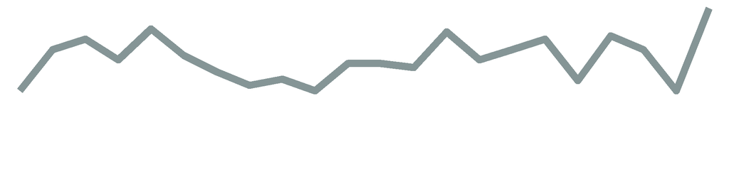

Matthew Rogers

9

10

11

8

14

9

10

NA

7

6

11

7

8

10

9

10

14

9

6

2

0

1

1

21

0.6404

0.6113

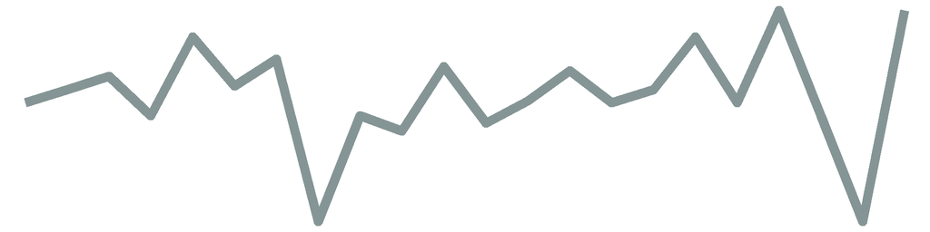

Welvin Lucero

8

9

10

NA

12

9

NA

9

9

7

10

NA

9

11

NA

NA

NA

8

4

0

1

1

1

16

0.6126

0.4455

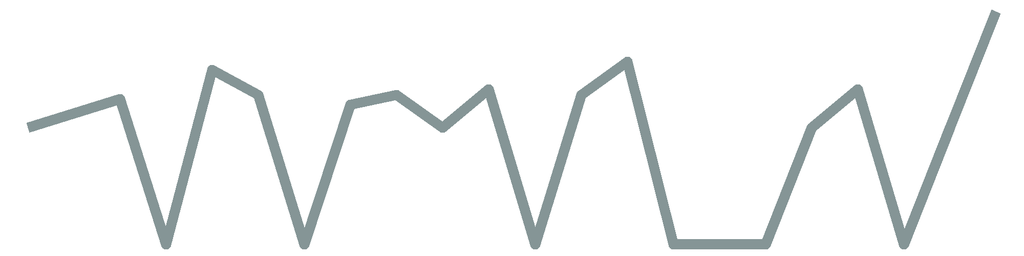

Gabriel Costa

8

8

10

8

11

11

9

6

5

7

9

11

10

10

8

10

12

NA

4

2

1

1

1

21

0.6075

0.5799

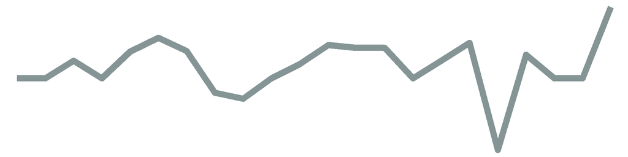

Blake Schwartz

10

6

8

6

11

9

9

9

7

5

9

6

9

9

10

11

12

10

5

1

1

1

1

22

0.5836

0.5836

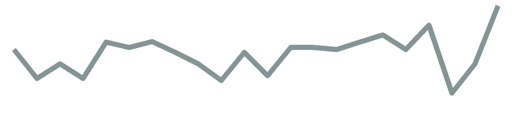

Eric Swenson

9

8

7

7

11

10

9

7

6

7

8

9

7

8

9

10

13

7

5

1

1

1

1

22

0.5694

0.5694

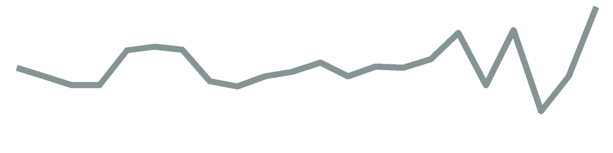

Ira Crofford

7

11

12

9

12

10

10

9

8

7

10

7

9

10

9

12

11

10

4

1

1

0

0

22

0.6370

0.6370

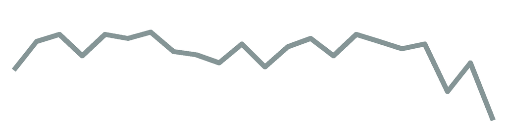

Jeremy Reynolds

8

11

9

10

13

10

9

9

7

7

11

7

8

11

10

9

12

8

5

2

1

0

0

22

0.6299

0.6299

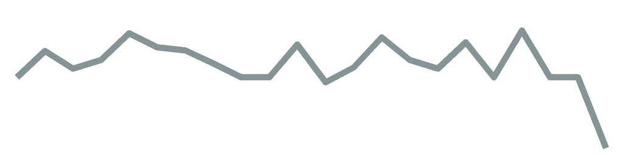

Michael Prokos

9

13

11

NA

12

8

9

7

8

7

8

8

9

11

10

10

11

9

4

1

1

0

0

21

0.6264

0.5979

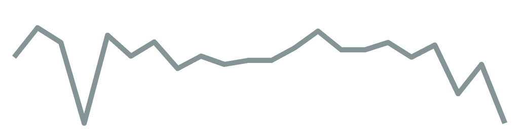

Daniel Baller

8

9

12

9

12

9

9

9

10

5

8

6

9

10

10

10

12

8

5

1

1

0

0

22

0.6121

0.6121

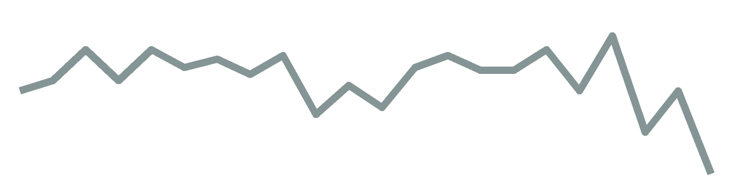

Jonathan Roginski

6

10

10

11

13

9

10

7

7

6

10

10

9

9

10

11

NA

8

4

2

0

0

0

21

0.6113

0.5835

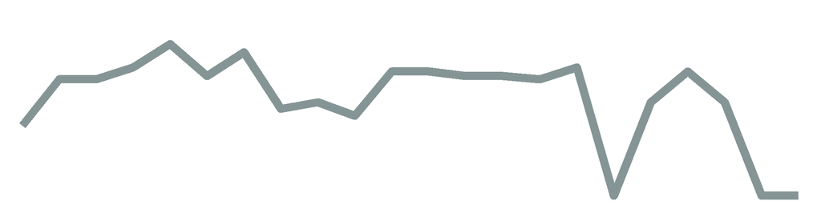

Leslie Jones

15

9

10

10

7

9

9

10

8

NA

6

NA

6

NA

NA

NA

NA

NA

NA

NA

NA

0

0

12

0.6111

0.3333

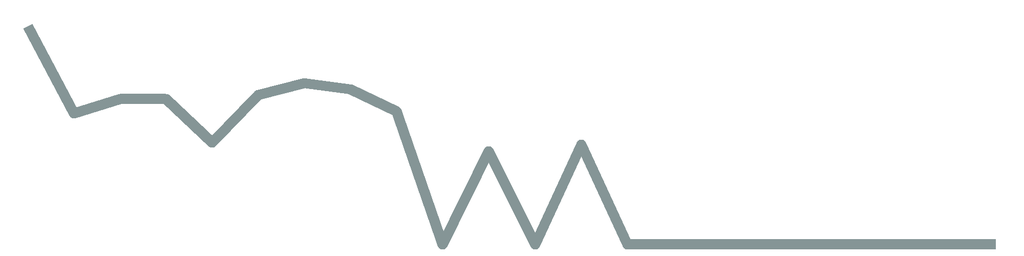

William Freiberg

10

10

9

10

13

9

9

9

8

6

9

8

9

10

9

NA

NA

8

5

0

1

0

0

20

0.6104

0.5549

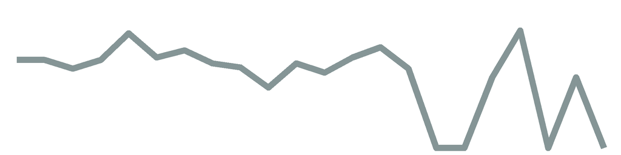

Patrick Mugg

7

8

11

7

9

10

8

9

5

6

8

7

9

8

11

NA

13

9

5

2

NA

0

0

20

0.5779

0.5254

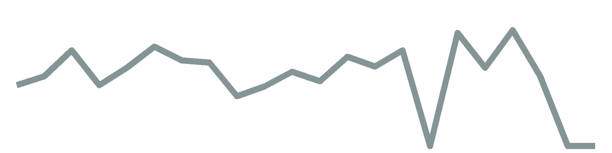

Cherri Gound

10

6

10

9

11

9

10

7

6

6

7

6

9

10

11

NA

10

8

4

1

2

0

0

21

0.5736

0.5475

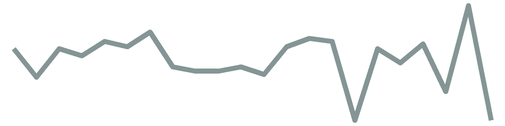

Josephine Cammack

9

9

6

8

12

8

9

8

4

6

6

8

9

9

9

10

13

8

4

1

1

0

0

22

0.5587

0.5587

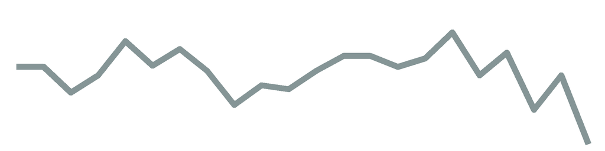

Kevin Cummiskey

9

8

10

NA

10

9

NA

8

6

NA

NA

5

9

10

7

NA

10

9

5

0

0

0

0

17

0.5502

0.4252

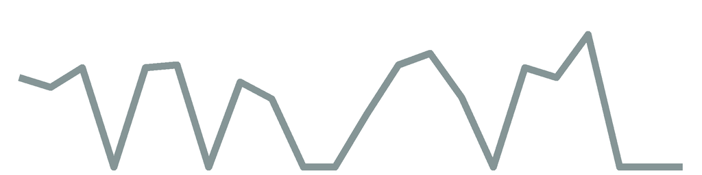

Margaret Grogan

6

10

10

9

10

7

7

9

9

8

7

5

9

8

10

6

6

8

4

1

2

0

0

22

0.5374

0.5374

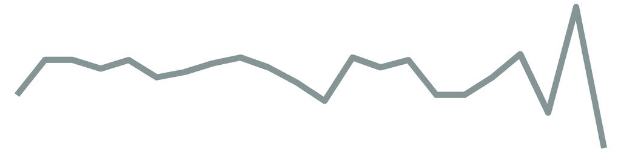

Tina Hartley

8

8

8

6

9

8

7

8

4

5

6

9

9

9

7

12

NA

6

4

1

2

0

0

21

0.5132

0.4899

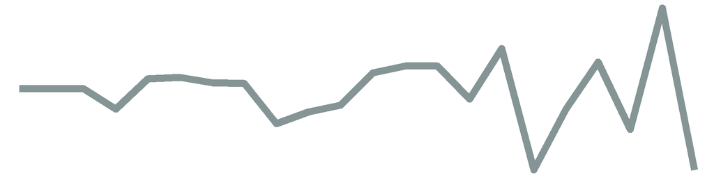

Nicholas Reisweber

11

10

9

7

10

9

10

9

NA

5

10

9

9

8

7

NA

NA

NA

NA

NA

NA

NA

0

14

0.5971

0.3800

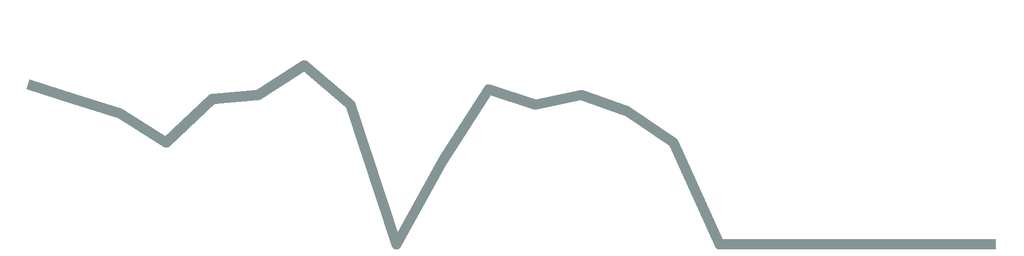

Shane Clark

5

11

7

NA

12

11

8

8

NA

7

9

7

9

9

9

12

11

7

5

1

1

NA

0

19

0.5960

0.5147

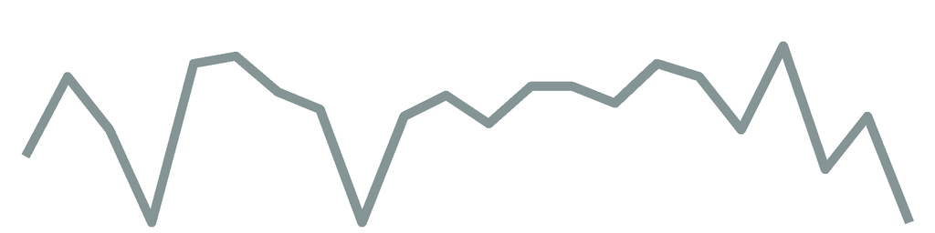

John Kearby

8

10

12

10

11

8

NA

8

8

5

9

NA

NA

NA

NA

NA

NA

NA

NA

NA

NA

NA

0

10

0.5933

0.2697

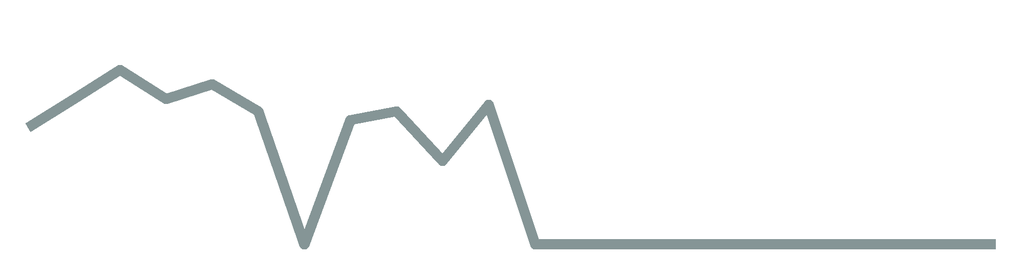

James Starling

7

11

9

10

11

9

6

9

6

5

8

9

7

11

9

10

11

9

NA

NA

NA

NA

0

18

0.5858

0.4793

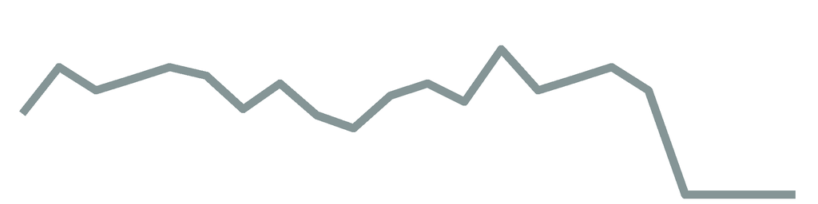

Evangeline Reynolds

8

8

NA

11

11

6

NA

NA

NA

NA

NA

NA

NA

NA

NA

NA

NA

9

NA

NA

NA

NA

0

6

0.5699

0.1554

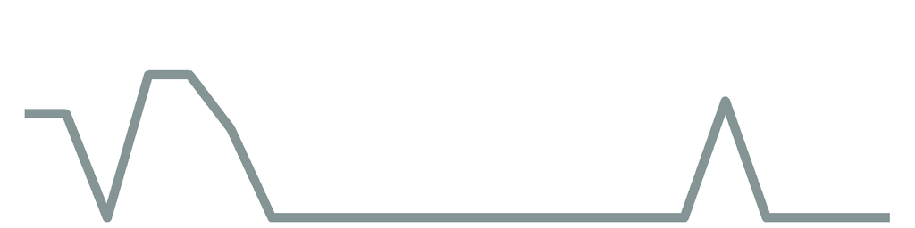

Margaret Wieczorek

8

10

9

9

11

8

9

8

5

5

7

NA

8

7

10

NA

NA

NA

NA

NA

NA

NA

0

14

0.5561

0.3539

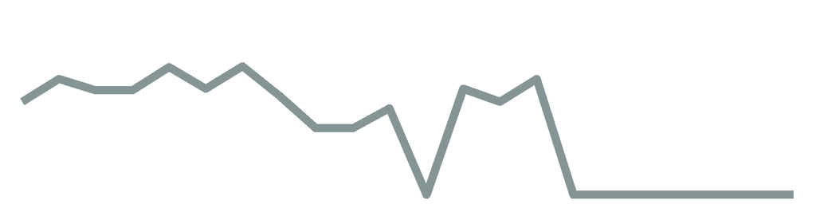

Alexander Withenbury

9

8

6

11

4

5

3

5

8

5

NA

NA

NA

NA

NA

NA

NA

NA

NA

NA

NA

NA

0

10

0.4384

0.1993

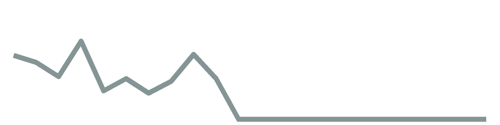

### Individual Plots

[interactive chart not shown]